# Practical Machine Learning course project

Nageswara Yedida

July 2, 2018

### Background

Using devices such as Jawbone Up, Nike FuelBand, and Fitbit it is now possible to collect a large amount of data about personal activity relatively inexpensively. One thing that people regularly do is quantify how much of a particular activity they do, but they rarely quantify how well they do it. In this project, the goal is to use data from accelerometers on the belt, forearm, arm, and dumbell of 6 participants. They were asked to perform barbell lifts correctly and incorrectly in 5 different ways. More information is available from the website here: http://web.archive.org/web/20161224072740/http:/groupware.les.inf.pucrio. br/har (see the section on the Weight Lifting Exercise Dataset).

### Getting Data

The training data for this project are available at: https://d396qusza40orc.cloudfront.net/predmachlearn/pml-training.csv The test data are available at: https://d396qusza40orc.cloudfront.net/predmachlearn/pml-testing.csv

We will load the data using R.

```r
hartrain <- read.csv("https://d396qusza40orc.cloudfront.net/predmachlearn/pml-training.csv", stringsAsFactors = FALSE, na.strings = c("NA","#DIV/0!", ""))
hartest <- read.csv("https://d396qusza40orc.cloudfront.net/predmachlearn/pml-testing.csv", stringsAsFactors = FALSE, na.strings = c("NA","#DIV/0!", ""))
```

### Cleaning Data

A quick look at the data reveals that there are many variables containing predominantly NA values. We will remove variables that have more than 95% NA values, from the list of predictors.

```r
z <- apply(hartrain, 2, function(col)sum(is.na(col))/length(col))
nacolumns <- z[z > .95]

har.tr <- hartrain[, !names(hartrain) %in% names(nacolumns)]
```

Also the first 7 columns are not device readings related to the work out and are omitted from the list of predictors.

```r
har.tr <- har.tr[, -c(1:7)]
```

### Predicting with Trees

Using caret package a tree model is fit to the data utilizing the CART model’s rpart method.

```r
library(caret)
modFit1 <- train(classe ~., method = "rpart", data = har.tr)
modFit1 <- caret::train(classe ~ ., method = "rpart", data = har.tr,
                       trControl=trainControl(method="none"),
                       tuneGrid=data.frame(cp=0.01))
```

```r
library(rattle)
```

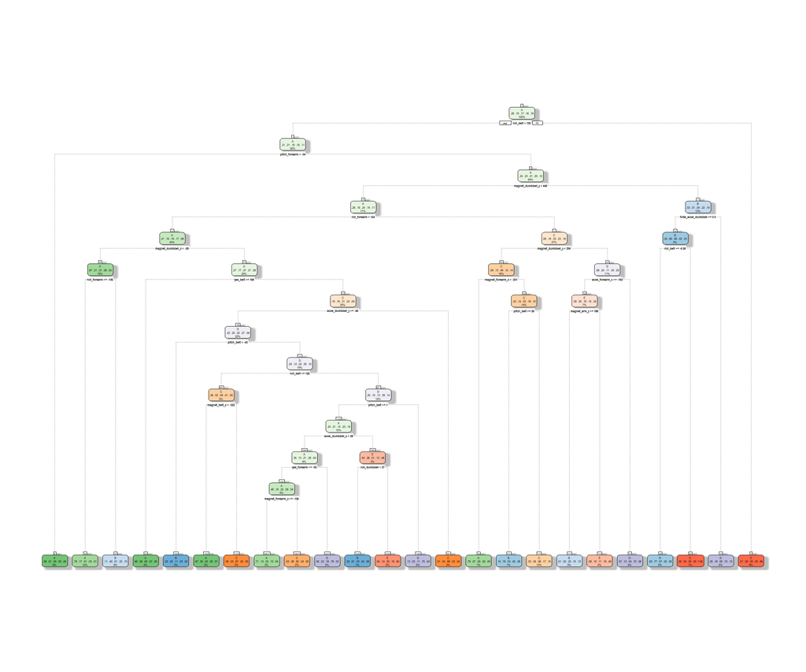

```r
fancyRpartPlot(modFit1$finalModel, sub = "")
```

```r
predictions1 <- predict(modFit1, newdata = har.tr[,-53])
confusionMatrix(predictions1, factor(har.tr$classe))
```

```
## Confusion Matrix and Statistics
##
##           Reference
## Prediction    A    B    C    D    E
##          A 4984  585   51  185   63
##          B  178 2414  310  277  316
##          C  139  367 2778  482  437
##          D  183  246  193 2045  185
##          E   96  185   90  227 2606
##
## Overall Statistics
##
##                Accuracy : 0.7556
##                  95% CI : (0.7496, 0.7616)
##     No Information Rate : 0.2844
##     P-Value [Acc > NIR] : < 2.2e-16
##
##                   Kappa : 0.6904
##  Mcnemar's Test P-Value : < 2.2e-16
##
## Statistics by Class:
##
##                      Class: A Class: B Class: C Class: D Class: E
## Sensitivity            0.8932   0.6358   0.8118   0.6359   0.7225
## Specificity            0.9370   0.9317   0.9120   0.9508   0.9627
## Pos Pred Value         0.8494   0.6907   0.6610   0.7170   0.8134
## Neg Pred Value         0.9567   0.9142   0.9582   0.9302   0.9390
## Prevalence             0.2844   0.1935   0.1744   0.1639   0.1838
## Detection Rate         0.2540   0.1230   0.1416   0.1042   0.1328
## Detection Prevalence   0.2991   0.1781   0.2142   0.1453   0.1633
## Balanced Accuracy      0.9151   0.7837   0.8619   0.7933   0.8426
```

This tree model resulted in around 75% classification accuracy. As can be seen from the confusion matrix a singnificant instances have been misclassified. We can improve the prediction accuracy using a randomForest algorithm which is known to fit models with high accuracy.

```r
set.seed(95014)
inTraining <- createDataPartition(har.tr$classe, p = .75, list=FALSE)
training <- har.tr[inTraining,]
testing <- har.tr[-inTraining,]

x <- training[,-53]
y <- training[,53]
# We will configure caret to do 5 fold cross validation while fitting the model
fitControl <- trainControl(method = "cv", number = 5, allowParallel = TRUE)
```

```r
fit <- train(x,y, method="rf", trControl = fitControl)
fit
```

```
## Random Forest
##
## 14718 samples
##    52 predictor
##     5 classes: 'A', 'B', 'C', 'D', 'E'
##
## No pre-processing
## Resampling: Cross-Validated (5 fold)
## Summary of sample sizes: 11775, 11774, 11775, 11775, 11773
## Resampling results across tuning parameters:
##
##   mtry  Accuracy   Kappa
##    2    0.9910998  0.9887402
##   27    0.9911676  0.9888270
##   52    0.9883139  0.9852164
##
## Accuracy was used to select the optimal model using the largest value.
## The final value used for the model was mtry = 27.
```

The model was fit by generating 500 trees and 5-fold cross validation was done as configured.

```r
fit$finalModel
```

```
##
## Call:
##  randomForest(x = x, y = y, mtry = param$mtry)
##                Type of random forest: classification
##                      Number of trees: 500
## No. of variables tried at each split: 27
##
##         OOB estimate of  error rate: 0.64%
## Confusion matrix:
##      A    B    C    D    E  class.error
## A 4181    2    1    0    1 0.0009557945
## B   18 2823    6    1    0 0.0087780899
## C    0   12 2548    7    0 0.0074016362
## D    0    0   28 2381    3 0.0128524046
## E    0    1    5    9 2691 0.0055432373
```

It was robust model fit as indicated by the expected out of sample error rate of 0.64%. We can now use the model to do prediction on the held out test set.

```r
predictionsRF <- predict(fit, testing[,-53])
confusionMatrix(predictionsRF, factor(testing$classe))
```

```
## Confusion Matrix and Statistics
##
##           Reference
## Prediction    A    B    C    D    E
##          A 1394    6    0    0    0
##          B    1  938    2    0    0
##          C    0    5  850    6    0
##          D    0    0    3  798    2
##          E    0    0    0    0  899
##
## Overall Statistics
##
##                Accuracy : 0.9949
##                  95% CI : (0.9925, 0.9967)
##     No Information Rate : 0.2845
##     P-Value [Acc > NIR] : < 2.2e-16
##
##                   Kappa : 0.9936
##  Mcnemar's Test P-Value : NA
##
## Statistics by Class:
##
##                      Class: A Class: B Class: C Class: D Class: E
## Sensitivity            0.9993   0.9884   0.9942   0.9925   0.9978
## Specificity            0.9983   0.9992   0.9973   0.9988   1.0000
## Pos Pred Value         0.9957   0.9968   0.9872   0.9938   1.0000
## Neg Pred Value         0.9997   0.9972   0.9988   0.9985   0.9995
## Prevalence             0.2845   0.1935   0.1743   0.1639   0.1837
## Detection Rate         0.2843   0.1913   0.1733   0.1627   0.1833
## Detection Prevalence   0.2855   0.1919   0.1756   0.1637   0.1833
## Balanced Accuracy      0.9988   0.9938   0.9957   0.9957   0.9989
```

The prediction accuracy of 99.49% indicates a pretty good prediction. The resulting actual test error rate of 0.51% is close to the OOB estimate as given by model fit above.

We can get the variable importance from the model. The top 10 vaiables are plotted here.

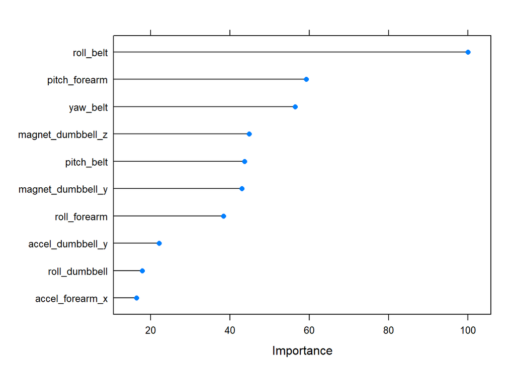

```r
plot(varImp(fit), top = 10)
```